# CA2

**In The Name Of God**

University of Tehran  
Hidden Markov Model  
CA2

Mobina Haghizadeh  
810100127

This notebook covers the topic of Hidden Markov Models (HMMs) and demonstrates their application in sound classification through the extraction of audio features.

## Description

In this problem, we have a dataset with recordings from 6 different broadcasters, each pronouncing numbers 0 to 9 50 times. We aim to use an HMM model to classify each audio sample and then evaluate the model’s performance. The classification is based on extracting Mel Frequency Cepstral Coefficients (MFCC) from each audio, which can provide valuable information for this task.

## Imports

```python
import numpy as np
from pathlib import Path
import re
import os
import glob
from sklearn.model_selection import train_test_split
import matplotlib.pyplot as plt
from hmmlearn import hmm
from python_speech_features import mfcc as Mfcc
import matplotlib.pyplot as plt
from scipy.io import wavfile
from scipy.stats import multivariate_normal
import sklearn.metrics as sk_metrics
import librosa
```

```python
recorders_name = ['george', 'jackson', 'lucas', 'nicolas', 'theo', 'yweweler']
digit_labels = ['0', '1', '2', '3', '4', '5', '6', '7', '8', '9']
minimum_audio_frame = 2985
Digit = "Digit"
Speaker = "Speaker"
metrics = ["accuracy", "precision", "recall", "f1_score"]
average_methods = ["macro", "micro", "weighted"]
```

# First Part:

Preprocessing and attribute extraction

## Question 1:

Yes, in this dataset with 6 different broadcasters each pronouncing numbers 0 to 9 for 50 times, segmentation can be useful for several reasons:

- Feature extraction: Segmentation can help in extracting features specific to each broadcaster’s pronunciation style. This can help in building more accurate models for speaker identification or speech recognition tasks.
- Model evaluation: By segmenting the dataset based on broadcasters, you can evaluate the performance of models on each broadcaster separately. This can provide insights into how well the models generalize across different broadcasters.
- Data quality control: Segmentation can help in identifying and addressing any issues specific to certain broadcasters, such as variations in pronunciation or recording quality. This can lead to improved data quality and model performance.

Overall, segmentation can enhance the analysis and modeling of the dataset by providing a more granular view of the data based on the different broadcasters.

## Question 2:

- MFCC (Mel Frequency Cepstral Coefficients): MFCC is a widely used feature representation for audio signals. It involves a series of mathematical operations to extract features that are representative of the spectral characteristics of the audio. The process includes dividing the audio signal into short frames, applying the Fourier Transform to each frame to obtain the power spectrum, mapping the power spectrum onto the mel scale (which is a perceptual scale of pitches), and finally applying the discrete cosine transform (DCT) to obtain a compact representation of the spectral features.
- Zero Crossing Rate: The zero crossing rate is a measure of how frequently the audio waveform changes its sign (from positive to negative or vice versa). It provides information about the rate of changes in the audio signal and can be used to estimate properties such as pitch and timbre. Signals with higher zero crossing rates tend to have more high-frequency content or noise, while signals with lower rates tend to be smoother or have lower frequency content.
- Mel Spectrogram: A spectrogram is a visual representation of how the frequencies of a signal vary over time. The mel spectrogram is a modified version of the traditional spectrogram that uses the mel scale to represent the frequency axis. The mel scale is a perceptual scale that better aligns with human auditory perception. By computing the mel spectrogram, we can obtain a representation of the audio signal that highlights the distribution of energy across different frequency bands over time.
- Chroma Features: Chroma features are a representation of the musical pitch content of an audio signal. They provide a compact way to describe the harmonic content of a signal by mapping the audio spectrum onto a set of 12 distinct pitch classes, corresponding to the 12 notes in the Western music scale. The chroma representation is useful for tasks such as music genre classification, chord recognition, and melody extraction.

In terms of their relationships, these audio attributes are often used together in audio signal processing tasks. Here's a high-level overview of their connections:

- MFCCs and mel spectrograms are closely related. MFCCs are derived from the mel spectrogram by applying the DCT to the mel-filterbank energies. Both representations capture the spectral content of the audio signal, with MFCCs being a more compact representation suitable for many applications.
- Zero crossing rate can be used in conjunction with other features to infer certain characteristics of the audio signal. For example, it can be used as a feature to distinguish between voiced and unvoiced speech or to estimate the periodicity of a signal.
- Chroma features are often derived from the mel spectrogram by summing or averaging the energy within each pitch class. They provide a way to capture the tonal content or musical characteristics of an audio signal, which can be useful for tasks related to music analysis and understanding.

Overall, these attributes provide complementary information about different aspects of the audio signal, such as its spectral content, temporal variations, harmonic properties, and tonal characteristics. By combining these features or using them in specific applications, we can gain insights into the acoustic properties of the audio and enable various audio processing tasks.

## Extracting MFCC Coefficients

```python
max_frames = 30
def extract_mfcc(audio_files):
    mfccs_list = []
    for audio_file in audio_files:
        sampling_rate, audio = wavfile.read(audio_file)
        audio, _ = librosa.effects.trim(audio, top_db=50, frame_length=1024)

        mfcc = Mfcc(audio, samplerate=sampling_rate, nfft=1024) [:30, :]
        current_frames = mfcc.shape[0]
        if current_frames < max_frames:
            pad_width = ((0, max_frames - current_frames), (0, 0))
            padded_mfcc = np.pad(mfcc, pad_width=pad_width, mode='constant', constant_values=0)
        else:
            padded_mfcc = mfcc[:max_frames, :]

        mfccs_list.append(padded_mfcc)

    return mfccs_list
```

```python
def plot_mfcc_heatmap(title, mfccs_array):
    plt.matshow(mfccs_array[0].T, cmap='Spectral',origin='lower', aspect='auto')
    plt.title(f"{title}'s voice MFCC heatmap")
    plt.ylabel('Coefficients')
    plt.xlabel('Time')
    plt.colorbar()
    plt.show()
```

## Target variable = Digit label

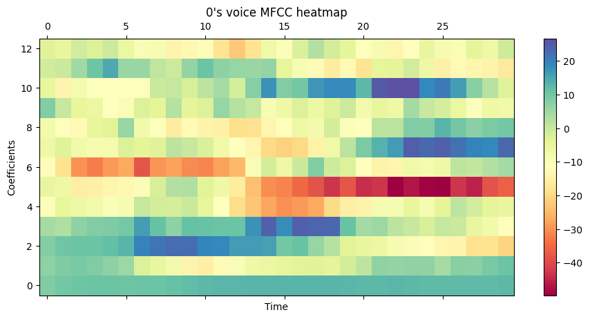

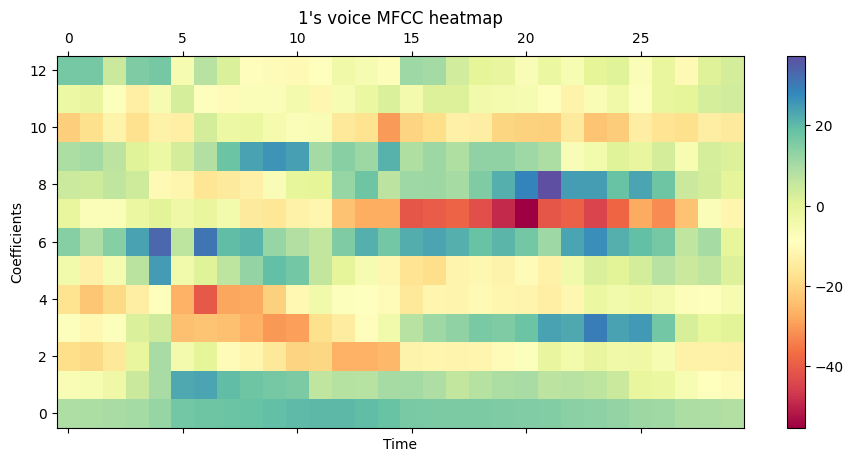

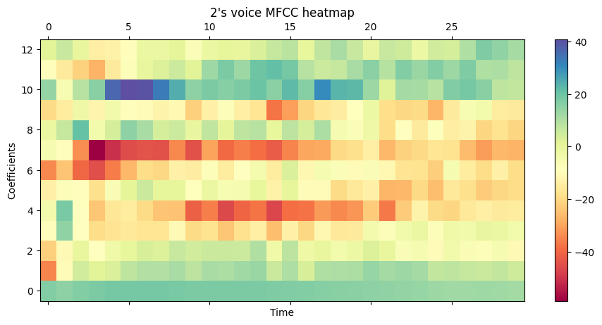

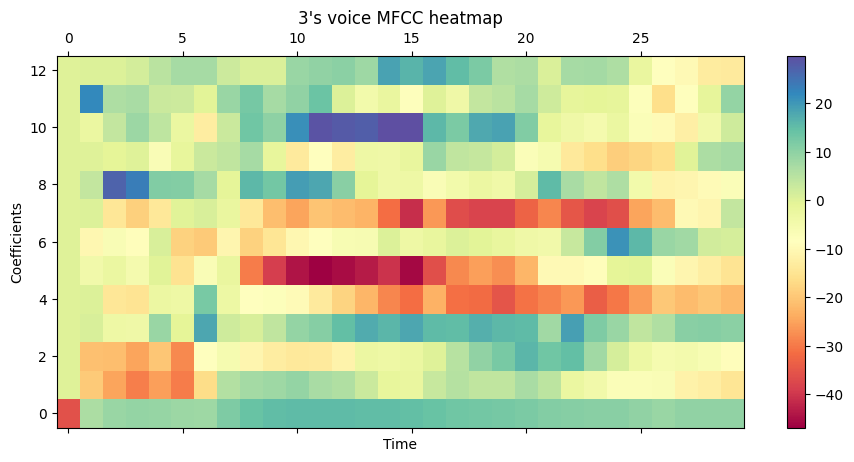

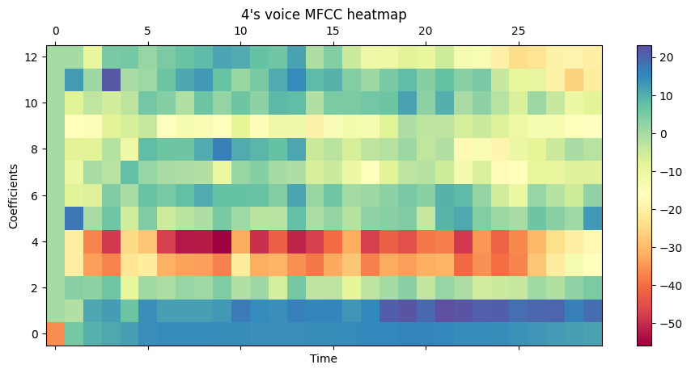

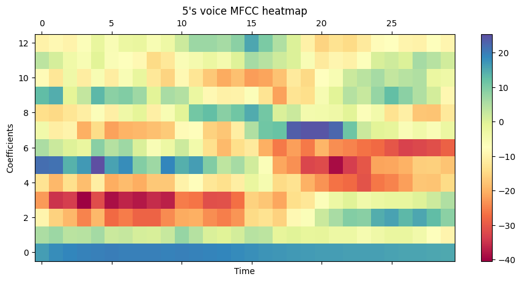

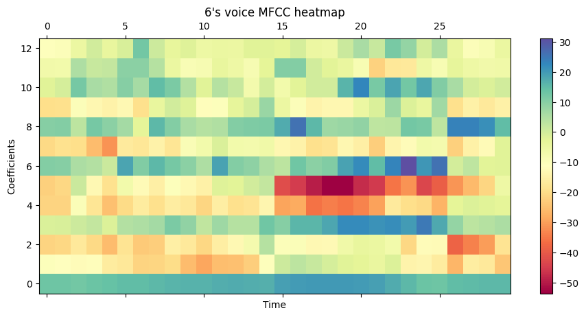

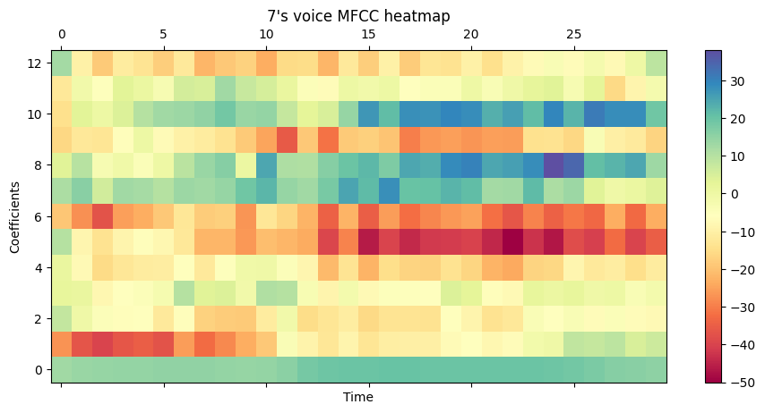

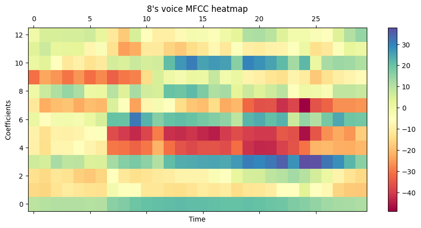

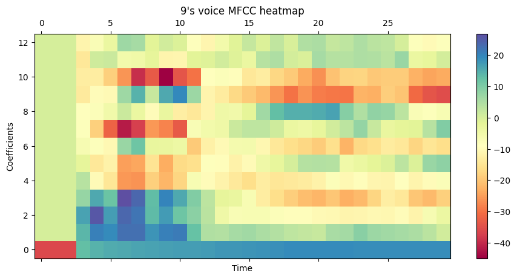

```python
digit_total_mfccs = []
total_digits = []



for i in range(len(digit_labels)):

    directory = f"{Path().absolute()}/recordings/"
    digit_sound = glob.glob(os.path.join(directory, f"{digit_labels[i]}*.wav"))
    mfccs_array = extract_mfcc(digit_sound)
    digit_total_mfccs.append(mfccs_array)
    total_digits.append([i] * len(mfccs_array))
    plot_mfcc_heatmap(digit_labels[i], mfccs_array)
```

## Target variable = Speaker name

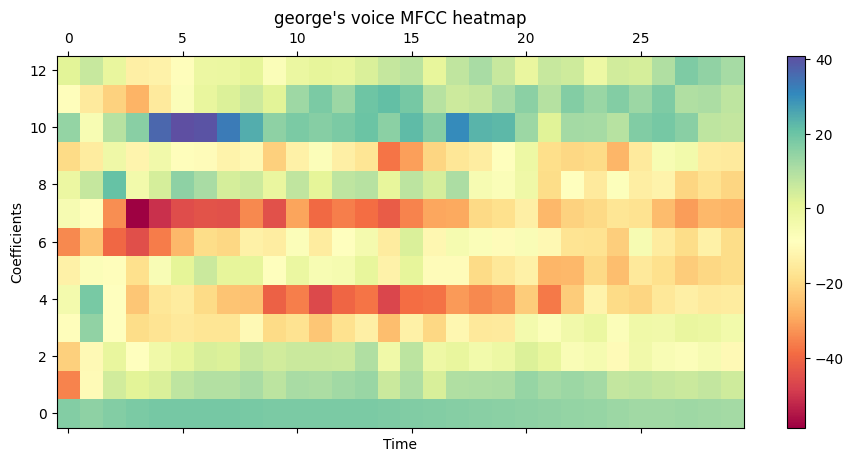

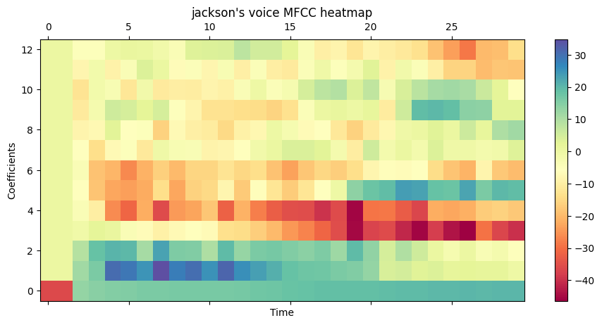

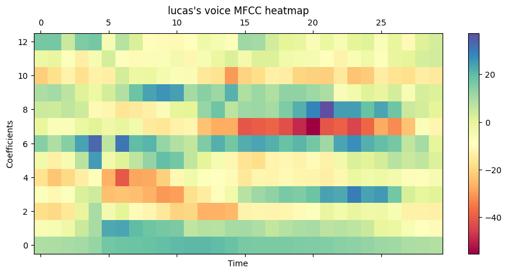

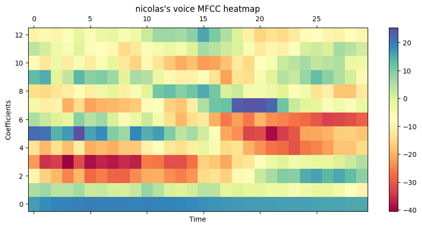

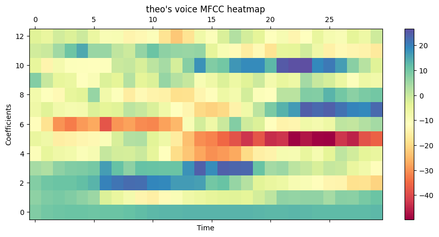

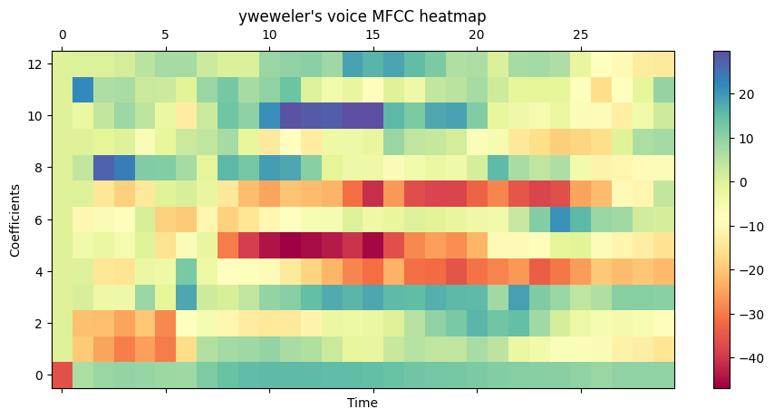

```python
recorders_total_mfccs = []
total_recorders = []



for i in range(len(recorders_name)):

    directory = f"{Path().absolute()}/recordings/"
    recorder_audios = glob.glob(os.path.join(directory, f"*{recorders_name[i]}*.wav"))
    mfccs_array = extract_mfcc(recorder_audios)
    recorders_total_mfccs.append(mfccs_array)
    total_recorders.append([i] * len(mfccs_array))
    plot_mfcc_heatmap(recorders_name[i], mfccs_array)
```

## Question 3:

1. Robustness: MFCCs are generally sensitive to small variations in input audio signals. This means that even minor changes in audio signals can have a significant impact on the MFCC values. Therefore, MFCCs are considered to be sensitive features in the extraction and analysis of audio signals.
2. Sensitivity: MFCCs are sensitive to changes in the diversity of audio features. These features can reflect variations in judgments about speaker identities, different speech states, and environmental conditions such as noise or speech deviations.

In summary, MFCCs are recognized as one of the most useful extraction features for processing audio signals. However, it is important to consider their sensitivity to variations when analyzing and utilizing them.

## Question 4:

Yes, there are specific factors that can improve the effectiveness of MFCC (Mel Frequency Cepstral Coefficients) for audio processing tasks. Some of these factors include:

1. Pre-processing Techniques: Applying pre-processing techniques such as using pre-emphasis filters or applying time-frequency masking can help highlight important signal information and provide a better representation of linguistic features.
2. Adjustment of MFCC Parameters: Tuning the parameters of MFCC such as the number of discrete frequencies, the size of the time window, the window shift, etc., can significantly improve performance. Experimenting with different settings can optimize the feature extraction process.
3. Dynamic Features: Incorporating dynamic features like delta and delta-delta coefficients can capture the temporal variations in the signal, providing richer information about the speech signal's dynamics.
4. Feature Normalization: Normalizing the MFCC features across time or frequency can enhance robustness to variations in input signals and improve generalization.
5. Contextual Information: Utilizing contextual information or combining MFCC features with other complementary features (e.g., pitch, energy, formants) can further enhance the discriminative power of the feature set.
6. Model Optimization: Optimizing the machine learning or signal processing models that utilize MFCC features can also impact the overall effectiveness. Choosing appropriate models and fine-tuning hyperparameters based on MFCC inputs can lead to better performance.
7. Data Augmentation: Increasing the diversity of training data through techniques like data augmentation (e.g., adding noise, shifting pitch) can help in learning more robust MFCC representations.

By considering and experimenting with these factors, practitioners can optimize the usage of MFCC coefficients for various speech and audio processing applications such as speech recognition, speaker identification, and emotion recognition.

## Question 5:

Using overlapping frames in MFCC (Mel Frequency Cepstral Coefficients) extraction is advantageous because it helps capture the temporal dynamics of audio signals more effectively. By overlapping frames, we can smooth out abrupt changes in the signal and create a more continuous representation, which is beneficial for analyzing speech and other audio data. This approach reduces variability and enhances the stability of the extracted features, making them suitable for a wide range of audio analysis tasks. Overall, overlapping frames in MFCC calculation contribute to a more fluid and informative representation of the audio signal.

## Question 6:

The first set of MFCCs typically encapsulates key spectral and energy distribution features of audio signals. Using fewer frames to compute these MFCCs can reduce the feature dimensionality, which is beneficial for computational efficiency.

Focusing on the initial 12 or 13 MFCCs allows us to capture essential perceptual information while avoiding redundancy. Studies suggest that humans are more sensitive to lower-order MFCCs, emphasizing the importance of prioritizing these features for comprehensive information extraction from audio data.

# Second Part:

Familiarity with HMM

## Question 1:

- States: States in Hidden Markov Models (HMMs) can be described as the unobservable or hidden aspects of the system. These states represent underlying factors that generate the observable data (observations) in the model.
- Observation: Observations in Hidden Markov Models (HMMs) refer to the observable variables or evidence that we can directly measure or have access to. These observations are used to infer the hidden states of the model through statistical methods.

### If target variable = Digit label :

The process of obtaining observations involves extracting relevant features from the audio signal, where we use MFCC to retrieve these features.

## Question 2:

In a first-order model, the current state only depends on the state just before it. This means that the chance of moving to a certain state is decided by the state that came right before it, shown as $P(state_t | state_{t-1})$. This simplicity in dependency is denoted by the term "first-order" to distinguish it from higher-order Markov models, where transitions may depend on multiple preceding states. The distinction between different model orders lies in the number of previous states that influence the transition probabilities. For example, in a second-order model, the transition probability depends on the two most recent states ($state_{t-1}$ and $state_{t-2}$).

## Question 3:

HMMs are useful for analyzing sequential data such as event series or time series. They excel at modeling relationships between these events and can reveal how things evolve over time. HMMs are particularly effective when dealing with incomplete or noisy data. They can manage imperfect data and still provide reliable predictions or estimates based on available information. HMMs are valuable in scenarios where unobserved hidden factors or states influence the observed data, allowing for deeper insights into underlying processes.

Some practical use cases:

`Natural Language Processing (NLP):` In NLP, HMMs are used for tasks like part-of-speech tagging and named entity recognition. Words are observed symbols, and grammatical categories or entity labels are hidden states.

`Robotics and Control Systems:` HMMs can assist in robot navigation and control by modeling sequences of sensory inputs (camera images, sensor readings) and hidden states representing different environmental conditions or robot states (moving, stationary, obstacle detected).

`Bioinformatics:` HMMs are used in bioinformatics for tasks such as gene prediction, sequence alignment, and protein structure prediction. HMMs can model the sequential dependencies and hidden states within biological sequences like DNA, RNA, or protein sequences.

## Question 4:

`Advantages:`

- HMMs provide a probabilistic framework for modeling sequential data, allowing them to capture uncertainties and making the model more robust.
- They excel at capturing sequential dependencies in data, making them useful for time-series data analysis.
- HMMs are capable of handling missing data using the forward-backward algorithm, which can estimate the probability distribution of missing states or observations.
- HMMs offer a compact representation of the system, which is advantageous for efficient use of computational resources.

`Disadvantages:`

- HMMs assume that the observations are conditionally independent given the hidden states. This assumption may not hold in some real-world scenarios.
- The fixed state space in HMMs can restrict the model's ability to handle situations where the number or nature of states may change.
- HMMs are sensitive to the choice of initial parameters, and incorrect initialization may lead to convergence to suboptimal solutions.
- As the sequence length increases, HMMs tend to forget past states, which can limit their effectiveness in tasks requiring long-term memory.
- HMMs may struggle to model complex data distributions, especially when dealing with high-dimensional or continuous data, as they primarily rely on discrete state and emission distributions.

## Question 5:

1. `Coupled HMM:` Coupled HMMs are used for modeling dependencies between multiple sequences of observations. Each sequence has its own hidden state sequence, but the state transitions are coupled across sequences, capturing relationships between them.
2. `Continuous Observation HMM (COHMM):` COHMMs extend the traditional HMM to handle continuous observations, where emission probabilities are modeled using continuous probability distributions (e.g., Gaussian distributions). COHMMs are suitable for applications involving continuous data like speech or sensor signals.
3. `Input-Output HMM (IOHMM):` IOHMMs are a type of HMM where the emission probabilities depend not only on the hidden state but also on additional input variables. This allows IOHMMs to model more complex relationships between hidden states and observed data.
4. `Factored HMM:` Factored HMMs decompose the joint probability distribution of observations and hidden states into a product of smaller factors, which can simplify model training and inference in certain scenarios.
5. `Left-to-Right HMM:` A left-to-right HMM is a type of HMM where state transitions proceed in a strict left-to-right manner without cycles or transitions between states in the reverse direction. This structure is commonly used in speech recognition systems to model temporal sequences.

# Third Part:

Implemeting the HMM.

## First we prepare our dataset for training and testing.

### Target variable = Digit label

```python
digit_train_data = dict()
digit_test_data_x = []
digit_test_data_y = []

for i in range(len(digit_labels)):
    x_train, x_test, y_train, y_test = train_test_split(np.array(digit_total_mfccs[i]), np.array(total_digits[i]), test_size=0.2, random_state=30)
    digit_train_data[digit_labels[i]] = x_train.reshape((x_train.shape[0] * x_train.shape[1], x_train.shape[2]))
    digit_test_data_x.append(list(x_test))
    digit_test_data_y.append(y_test)

digit_test_data_x = np.array(digit_test_data_x)
digit_test_data_x = digit_test_data_x.reshape((digit_test_data_x.shape[0] * digit_test_data_x.shape[1], digit_test_data_x.shape[2], digit_test_data_x.shape[3]))
digit_test_data_y = np.array(digit_test_data_y).flatten()
```

### Target variable = Speaker name

```python
recorder_train_data = dict()
recorder_test_data_x = []
recorder_test_data_y = []

for i in range(len(recorders_name)):
    x_train, x_test, y_train, y_test = train_test_split(np.array(recorders_total_mfccs[i]), np.array(total_recorders[i]), test_size=0.2, random_state=42)
    recorder_train_data[recorders_name[i]] = x_train.reshape((x_train.shape[0] * x_train.shape[1], x_train.shape[2]))
    recorder_test_data_x.append(list(x_test))
    recorder_test_data_y.append(y_test)

recorder_test_data_x = np.array(recorder_test_data_x)
recorder_test_data_x = recorder_test_data_x.reshape((recorder_test_data_x.shape[0] * recorder_test_data_x.shape[1], recorder_test_data_x.shape[2], recorder_test_data_x.shape[3]))
recorder_test_data_y = np.array(recorder_test_data_y).flatten()
```

# Implementing with Libraries

### Target variable = Digit labels

We utilize the GaussianHMM model to train separate models for each digit label. Each digit's model is trained using its respective training data.

```python
digit_HMM_models = []

for digit in digit_labels:
    model = hmm.GaussianHMM(n_components=4, covariance_type='diag')
    model.fit(digit_train_data[digit])
    digit_HMM_models.append(model)
```

Now, for testing, we assign labels to each audio sample in the test dataset. We evaluate each audio sample using all of our trained models. The model that produces the highest score or likelihood for a given sample will be used to label that data point.

```python
digit_y_predictions = []

for i in range(digit_test_data_x.shape[0]):
    scores=[]
    for model in digit_HMM_models:
        scores.append(model.score(digit_test_data_x[i,:]))
    label = np.argmax(np.array(scores))
    digit_y_predictions.append(label)
```

### Target variable = Speaker name

We utilize the GaussianHMM model to train separate models for each speaker name. Each speaker name's model is trained using its respective training data.

```python
recorder_HMM_models = []

for recorder in recorders_name:
    model = hmm.GaussianHMM(n_components=4, covariance_type='diag')
    model.fit(recorder_train_data[recorder])
    recorder_HMM_models.append(model)
```

```python
recorder_y_predictions = []

for i in range(recorder_test_data_x.shape[0]):
    scores=[]
    for model in recorder_HMM_models:
        scores.append(model.score(recorder_test_data_x[i,:]))
    label = np.argmax(np.array(scores))
    recorder_y_predictions.append(label)
```

Then we plot the confusion matrix

```python
def plot_confusion_matrix(confusion_matrix, labels, target):
    plt.imshow(confusion_matrix, interpolation='nearest', cmap=plt.cm.YlGn)
    plt.title(target + ' Confusion Matrix')
    plt.colorbar()
    plt.xticks(np.arange(len(labels)), labels)
    plt.yticks(np.arange(len(labels)), labels)
    for i in range(len(labels)):
        for j in range(len(labels)):
            plt.text(j, i, str(confusion_matrix[i, j]), ha='center', va='center', color='black')
    plt.xlabel('Predicted Label')
    plt.ylabel('Real Label')
    plt.show()
```

```python
def generate_confusion_matrix(y, y_prediction, classes_num):

    confusion_matrix = np.zeros((classes_num, classes_num))
    for i in range(classes_num):
        for j in range(classes_num):
            confusion_matrix[i, j] = (
                np.sum((y == i) & (y_prediction == j)))/(len(y)/classes_num)

    return confusion_matrix
```

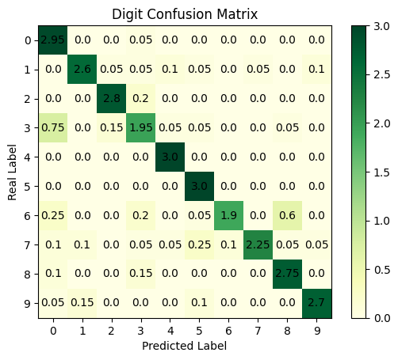

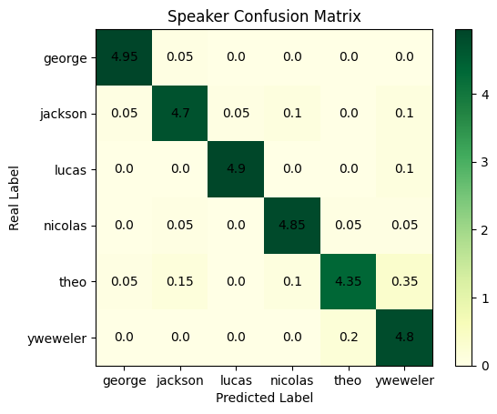

```python
digit_matrix = sk_metrics.confusion_matrix(digit_test_data_y, np.array(digit_y_predictions))/20
recorder_matrix = sk_metrics.confusion_matrix(recorder_test_data_y, np.array(recorder_y_predictions))/20
plot_confusion_matrix( digit_matrix, digit_labels, Digit)
plot_confusion_matrix(recorder_matrix, recorders_name, Speaker)
```